# Luxembourg Research Evaluation 2022

Daniel S. Hain

09 June, 2022

# 1 Initial Corpus generation

# 2 General Overview over articles

## 2.1 Main Indicators: Publications, Authors, Countries

To start with, a general overview over the documents in the corpus.

```
MAIN INFORMATION ABOUT DATA

 Timespan                              2016 : 2021
 Sources (Journals, Books, etc)        1583
 Documents                             9316
 Average years from publication        3.44
 Average citations per documents       28.57
 Average citations per year per doc    6.014
 References                            392759

DOCUMENT TYPES
 article               9245
 book chapter          8
 conference paper      3
 data paper            1
 editorial             8
 review                50
 short survey          1

DOCUMENT CONTENTS
 Keywords Plus (ID)                    38582
 Author's Keywords (DE)                15037

AUTHORS
 Authors                               55452
 Author Appearances                    105619
 Authors of single-authored documents  67
 Authors of multi-authored documents   55385

AUTHORS COLLABORATION
 Single-authored documents             71
 Documents per Author                  0.168
 Authors per Document                  5.95
 Co-Authors per Documents              11.3
 Collaboration Index                   5.99


Annual Scientific Production
```

| Year | Articles |
| --- | --- |
| 2016 | 1234 |
| 2017 | 1467 |
| 2018 | 1767 |
| 2019 | 1831 |
| 2020 | 1776 |
| 2021 | 1241 |

```
Annual Percentage Growth Rate 0.1131956


Most Productive Authors
```

|  | Authors | Articles | Authors | Articles Fractionalized |
| --- | --- | --- | --- | --- |
| 1 | WANG Y | 280 | WANG Y | 28.2 |
| 2 | LI Y | 213 | LI Y | 22.3 |
| 3 | WANG J | 204 | WANG J | 21.4 |
| 4 | ZHANG Y | 196 | WANG X | 20.4 |
| 5 | LIU Y | 190 | ZHANG Y | 20.3 |
| 6 | WANG X | 188 | LIU Y | 18.6 |
| 7 | ZHANG J | 163 | ZHANG J | 16.1 |
| 8 | WANG Z | 142 | WANG H | 14.4 |
| 9 | WANG L | 141 | ZHANG X | 13.9 |
| 10 | ZHANG H | 137 | WANG L | 13.5 |

```
Top manuscripts per citations
```

|  | Paper | DOI | TC | TCperYear | NTC |
| --- | --- | --- | --- | --- | --- |
| 1 | CHANDRASHEKAR DS, 2017, NEOPLASIA | 10.1016/j.neo.2017.05.002 | 2159 | 360 | 50.6 |
| 2 | TYANOVA S, 2016, NAT PROTOC | 10.1038/nprot.2016.136 | 1476 | 211 | 29.5 |
| 3 | CECCARELLI M, 2016, CELL | 10.1016/j.cell.2015.12.028 | 1083 | 155 | 21.7 |
| 4 | COLAPRICO A, 2016, NUCLEIC ACIDS RES | 10.1093/nar/gkv1507 | 1070 | 153 | 21.4 |
| 5 | LIAO M, 2020, NAT MED | 10.1038/s41591-020-0901-9 | 978 | 326 | 65.9 |
| 6 | CAPPER D, 2018, NATURE | 10.1038/nature26000 | 976 | 195 | 27.5 |
| 7 | LIU J, 2018, CELL | 10.1016/j.cell.2018.02.052 | 974 | 195 | 27.4 |
| 8 | GHANDI M, 2019, NATURE | 10.1038/s41586-019-1186-3 | 871 | 218 | 36.5 |
| 9 | HOADLEY KA, 2018, CELL | 10.1016/j.cell.2018.03.022 | 823 | 165 | 23.2 |
| 10 | STUPP R, 2017, JAMA | 10.1001/jama.2017.18718 | 792 | 132 | 18.5 |

```
Corresponding Author's Countries
```

|  | Country | Articles | Freq | SCP | MCP | MCP_Ratio |
| --- | --- | --- | --- | --- | --- | --- |
| 1 | USA | 2360 | 0.2682 | 1616 | 744 | 0.315 |
| 2 | CHINA | 1902 | 0.2161 | 1576 | 326 | 0.171 |
| 3 | GERMANY | 930 | 0.1057 | 419 | 511 | 0.549 |
| 4 | UNITED KINGDOM | 326 | 0.0370 | 136 | 190 | 0.583 |
| 5 | JAPAN | 300 | 0.0341 | 249 | 51 | 0.170 |
| 6 | FRANCE | 297 | 0.0337 | 147 | 150 | 0.505 |
| 7 | KOREA | 296 | 0.0336 | 230 | 66 | 0.223 |
| 8 | ITALY | 253 | 0.0287 | 168 | 85 | 0.336 |
| 9 | CANADA | 228 | 0.0259 | 123 | 105 | 0.461 |
| 10 | AUSTRALIA | 179 | 0.0203 | 100 | 79 | 0.441 |

```
SCP: Single Country Publications

MCP: Multiple Country Publications


Total Citations per Country
```

|  | Country | Total Citations | Average Article Citations |
| --- | --- | --- | --- |
| 1 | USA | 88951 | 37.69 |
| 2 | CHINA | 39057 | 20.53 |
| 3 | GERMANY | 30348 | 32.63 |
| 4 | UNITED KINGDOM | 11072 | 33.96 |
| 5 | FRANCE | 8220 | 27.68 |
| 6 | CANADA | 6715 | 29.45 |
| 7 | ITALY | 5745 | 22.71 |
| 8 | KOREA | 5640 | 19.05 |
| 9 | JAPAN | 4824 | 16.08 |
| 10 | NETHERLANDS | 4494 | 31.43 |

```
Most Relevant Sources
```

|  | Sources | Articles |
| --- | --- | --- |
| 1 | SCIENTIFIC REPORTS | 338 |
| 2 | NATURE COMMUNICATIONS | 269 |
| 3 | ONCOTARGET | 262 |
| 4 | NEURO-ONCOLOGY | 218 |
| 5 | CANCERS | 173 |
| 6 | PLOS ONE | 161 |
| 7 | JOURNAL OF NEURO-ONCOLOGY | 142 |
| 8 | CELL REPORTS | 133 |
| 9 | FRONTIERS IN IMMUNOLOGY | 122 |
| 10 | CANCER RESEARCH | 116 |

```
Most Relevant Keywords
```

|  | Author Keywords (DE) | Articles | Keywords-Plus (ID) | Articles |
| --- | --- | --- | --- | --- |
| 1 | GLIOBLASTOMA | 820 | HUMAN | 7477 |
| 2 | GLIOMA | 575 | ARTICLE | 7433 |
| 3 | AUTOPHAGY | 547 | FEMALE | 6511 |
| 4 | PROGNOSIS | 264 | HUMANS | 6207 |
| 5 | PROTEOMICS | 205 | MALE | 5496 |
| 6 | HYPOXIA | 204 | CONTROLLED STUDY | 5473 |
| 7 | MACHINE LEARNING | 196 | METABOLISM | 4524 |
| 8 | IMMUNOTHERAPY | 190 | GENETICS | 4210 |
| 9 | CANCER | 185 | GLIOBLASTOMA | 4037 |
| 10 | APOPTOSIS | 182 | PRIORITY JOURNAL | 3689 |

```
NA
```

And a graphical visualization

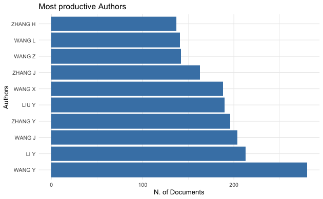

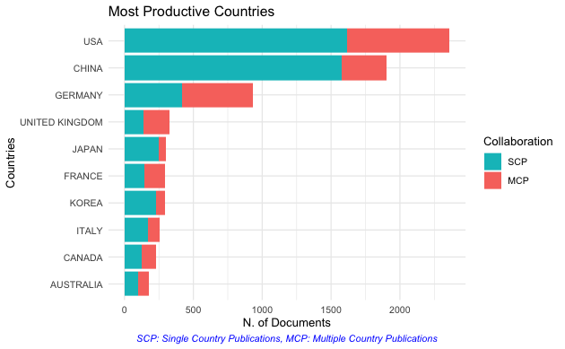

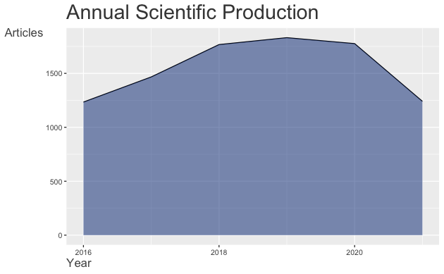

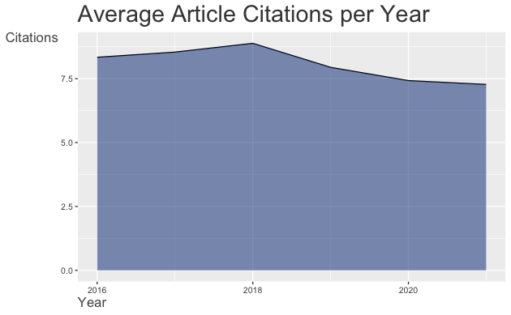

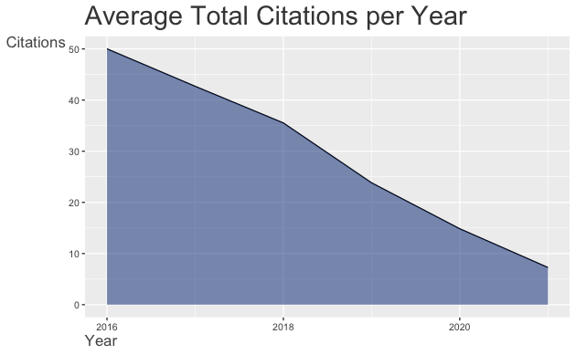

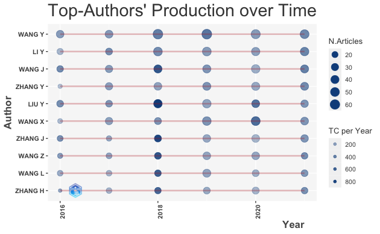

## 2.2 Cited references

Top 20 cited references (by corpus documents):

| CR | n |
| --- | --- |
| COX, J., MANN, M., MAXQUANT ENABLES HIGH PEPTIDE IDENTIFICATION RATES, INDIVIDUALIZED P.P.B.-RANGE MASS ACCURACIES AND PROTEOME-WIDE PROTEIN QUANTIFICATION (2008) NAT. BIOTECHNOL., 26, PP. 1367-1372 | 345 |
| HANAHAN, D., WEINBERG, R.A., HALLMARKS OF CANCER: THE NEXT GENERATION (2011) CELL, 144, PP. 646-674 | 219 |
| COX, J., NEUHAUSER, N., MICHALSKI, A., SCHELTEMA, R.A., OLSEN, J.V., MANN, M., ANDROMEDA: A PEPTIDE SEARCH ENGINE INTEGRATED INTO THE MAXQUANT ENVIRONMENT (2011) J. PROTEOME RES., 10, PP. 1794-1805 | 185 |
| TYANOVA, S., TEMU, T., SINITCYN, P., CARLSON, A., HEIN, M.Y., GEIGER, T., MANN, M., COX, J., THE PERSEUS COMPUTATIONAL PLATFORM FOR COMPREHENSIVE ANALYSIS OF (PROTE)OMICS DATA (2016) NAT. METHODS, 13,… | 183 |
| COMPREHENSIVE GENOMIC CHARACTERIZATION DEFINES HUMAN GLIOBLASTOMA GENES AND CORE PATHWAYS (2008) NATURE, 455, PP. 1061-1068 | 170 |
| COX, J., HEIN, M.Y., LUBER, C.A., PARON, I., NAGARAJ, N., MANN, M., ACCURATE PROTEOME-WIDE LABEL-FREE QUANTIFICATION BY DELAYED NORMALIZATION AND MAXIMAL PEPTIDE RATIO EXTRACTION, TERMED MAXLFQ (2014)… | 167 |
| COX, J., MANN, M., MAXQUANT ENABLES HIGH PEPTIDE IDENTIFICATION RATES, INDIVIDUALIZED P.P.B.-RANGE MASS ACCURACIES AND PROTEOME-WIDE PROTEIN QUANTIFICATION (2008) NAT BIOTECHNOL, 26, PP. 1367-1372 | 122 |
| RAPPSILBER, J., MANN, M., ISHIHAMA, Y., PROTOCOL FOR MICRO-PURIFICATION, ENRICHMENT, PRE-FRACTIONATION AND STORAGE OF PEPTIDES FOR PROTEOMICS USING STAGETIPS (2007) NAT. PROTOC., 2, PP. 1896-1906 | 122 |
| LOUIS, D.N., PERRY, A., REIFENBERGER, G., THE 2016 WORLD HEALTH ORGANIZATION CLASSIFICATION OF TUMORS OF THE CENTRAL NERVOUS SYSTEM: A SUMMARY (2016) ACTA NEUROPATHOL, 131, PP. 803-820 | 110 |
| LIAW, A., WIENER, M., CLASSIFICATION AND REGRESSION BY RANDOMFOREST (2002) R NEWS, 2, PP. 18-22 | 107 |
| LIAW, A., WIENER, M., CLASSIFICATION AND REGRESSION BY RANDOMFOREST (2002) R NEWS, 2 (3), PP. 18-22 | 97 |
| LOUIS, D.N., PERRY, A., REIFENBERGER, G., VON DEIMLING, A., FIGARELLA-BRANGER, D., CAVENEE, W.K., OHGAKI, H., ELLISON, D.W., THE 2016 WORLD HEALTH ORGANIZATION CLASSIFICATION OF TUMORS OF THE CENTRAL … | 92 |
| LOUIS, D.N., PERRY, A., REIFENBERGER, G., VON DEIMLING, A., FIGARELLA-BRANGER, D., CAVENEE, W.K., THE 2016 WORLD HEALTH ORGANIZATION CLASSIFICATION OF TUMORS OF THE CENTRAL NERVOUS SYSTEM: A SUMMARY (… | 91 |
| VERHAAK, R.G., HOADLEY, K.A., PURDOM, E., WANG, V., QI, Y., WILKERSON, M.D., INTEGRATED GENOMIC ANALYSIS IDENTIFIES CLINICALLY RELEVANT SUBTYPES OF GLIOBLASTOMA CHARACTERIZED BY ABNORMALITIES IN PDGFR… | 86 |
| VERHAAK, R.G., HOADLEY, K.A., PURDOM, E., WANG, V., QI, Y., WILKERSON, M.D., MILLER, C.R., MESIROV, J.P., INTEGRATED GENOMIC ANALYSIS IDENTIFIES CLINICALLY RELEVANT SUBTYPES OF GLIOBLASTOMA CHARACTERI… | 85 |
| BREIMAN, L., RANDOM FORESTS (2001) MACH. LEARN., 45, PP. 5-32 | 82 |
| YAN, H., PARSONS, D.W., JIN, G., IDH1 AND IDH2 MUTATIONS IN GLIOMAS (2009) N ENGL J MED, 360, PP. 765-773 | 80 |
| LI, H., DURBIN, R., FAST AND ACCURATE SHORT READ ALIGNMENT WITH BURROWS-WHEELER TRANSFORM (2009) BIOINFORMATICS, 25, PP. 1754-1760 | 78 |
| STUPP, R., MASON, W.P., VAN DEN BENT, M.J., WELLER, M., FISHER, B., TAPHOORN, M.J., RADIOTHERAPY PLUS CONCOMITANT AND ADJUVANT TEMOZOLOMIDE FOR GLIOBLASTOMA (2005) N ENGL J MED, 352, PP. 987-996 | 78 |
| DOBIN, A., DAVIS, C.A., SCHLESINGER, F., DRENKOW, J., ZALESKI, C., JHA, S., BATUT, P., GINGERAS, T.R., STAR: ULTRAFAST UNIVERSAL RNA-SEQ ALIGNER (2013) BIOINFORMATICS, 29, PP. 15-21 | 77 |

# 3 Topic modelling

## 3.1 Topics by topwords

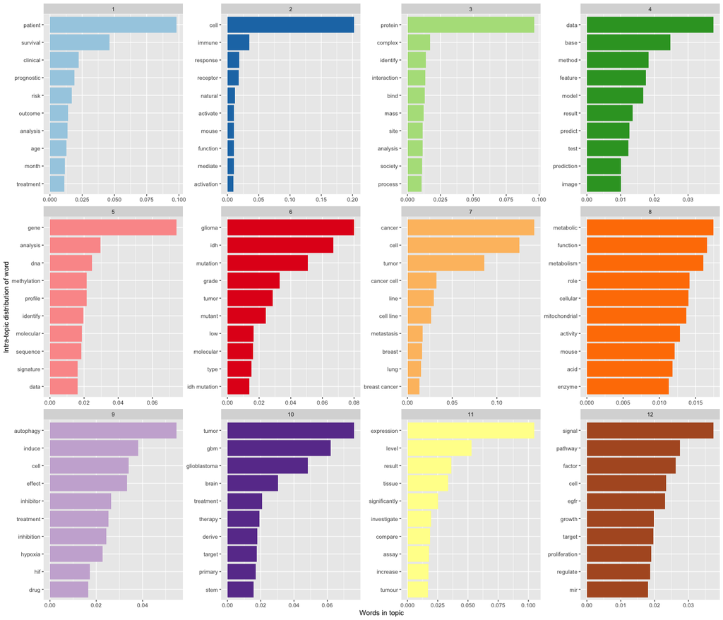

This might still be finetuned, but initially doesnt look that bad I think. All the topics for me seem to be somewhat identifiable. We should maybe start naming them to make their interpretation later easier.

## 3.2 Topics over time

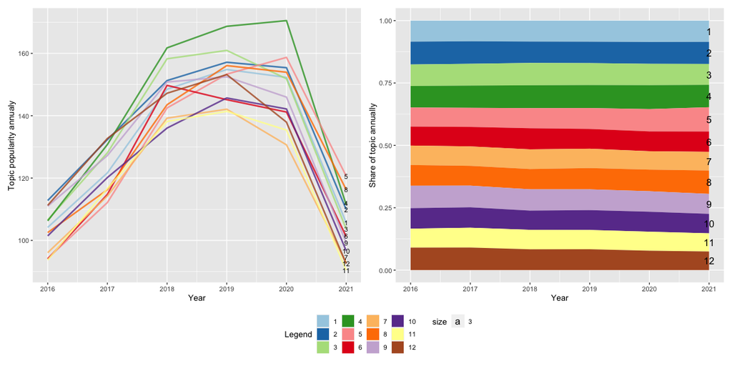

## 3.3 LDAViz

# 4 Knowledge Bases: Co-Citation network analysis

**Note:** This analysis refers the co-citation analysis, where the cited references and not the original publications are the unit of analysis. See tab `Technical description`for additional explanations

## 4.1 Knowledge Bases summary

### 4.1.1 Main Indicators

In order to partition networks into components or clusters, we deploy a **community detection** technique based on the **Lovain Algorithm** (Blondel et al., 2008). The Lovain Algorithm is a heuristic method that attempts to optimize the modularity of communities within a network by maximizing within- and minimizing between-community connectivity. We identify the following communities = knowledge bases.

| com_name | n | density_int |
| --- | --- | --- |
| 1 | 2487 | 1.395 |
| 2 | 2144 | 2.067 |
| 3 | 2105 | 2.118 |
| 4 | 2018 | 1.882 |
| 5 | 1933 | 2.250 |
| 6 | 1760 | 2.126 |
| 7 | 1741 | 3.179 |

| com | name | dgr_int | dgr |
| --- | --- | --- | --- |
| 1 | COX J. MANN M. MAXQUANT ENABLES HIGH PEPTIDE IDENTIFICATION RATES INDIVIDUALIZED P.P.B.-RANGE MASS ACCURACIES AND PROTEOME-WIDE PROTEIN QUANTIFICAT... | 9186 | 10106 |
| 1 | COX J. NEUHAUSER N. MICHALSKI A. SCHELTEMA R.A. OLSEN J.V. MANN M. ANDROMEDA: A PEPTIDE SEARCH ENGINE INTEGRATED INTO THE MAXQUANT ENVIRONMENT (2011) | 4417 | 4685 |
| 1 | COX J. HEIN M.Y. LUBER C.A. PARON I. NAGARAJ N. MANN M. ACCURATE PROTEOME-WIDE LABEL-FREE QUANTIFICATION BY DELAYED NORMALIZATION AND MAXIMAL PEPTI... | 3673 | 3940 |
| 1 | TYANOVA S. TEMU T. SINITCYN P. CARLSON A. HEIN M.Y. GEIGER T. MANN M. COX J. THE PERSEUS COMPUTATIONAL PLATFORM FOR COMPREHENSIVE ANALYSIS OF (PROTE) | 3152 | 3449 |
| 1 | RAPPSILBER J. MANN M. ISHIHAMA Y. PROTOCOL FOR MICRO-PURIFICATION ENRICHMENT PRE-FRACTIONATION AND STORAGE OF PEPTIDES FOR PROTEOMICS USING STAGETI... | 2937 | 3180 |
| 1 | COX J. ANDROMEDA: A PEPTIDE SEARCH ENGINE INTEGRATED INTO THE MAXQUANT ENVIRONMENT (2011) | 1270 | 1379 |
| 1 | TYANOVA S. THE PERSEUS COMPUTATIONAL PLATFORM FOR COMPREHENSIVE ANALYSIS OF (PROTE) | 1245 | 1469 |
| 1 | COX J. ACCURATE PROTEOME-WIDE LABEL-FREE QUANTIFICATION BY DELAYED NORMALIZATION AND MAXIMAL PEPTIDE RATIO EXTRACTION TERMED MAXLFQ (2014) | 990 | 1112 |
| 1 | KULAK N.A. PICHLER G. PARON I. NAGARAJ N. MANN M. MINIMAL ENCAPSULATED PROTEOMIC-SAMPLE PROCESSING APPLIED TO COPY-NUMBER ESTIMATION IN EUKARYOTIC ... | 681 | 704 |
| 1 | TYANOVA S. TEMU T. COX J. THE MAXQUANT COMPUTATIONAL PLATFORM FOR MASS SPECTROMETRY-BASED SHOTGUN PROTEOMICS (2016) | 649 | 689 |
| 2 | BRENNAN C.W. THE SOMATIC GENOMIC LANDSCAPE OF GLIOBLASTOMA (2013) | 1838 | 2007 |
| 2 | LOVE M.I. HUBER W. ANDERS S. MODERATED ESTIMATION OF FOLD CHANGE AND DISPERSION FOR RNA-SEQ DATA WITH DESEQ2 (2014) | 1557 | 2607 |
| 2 | PATEL A.P. SINGLE-CELL RNA-SEQ HIGHLIGHTS INTRATUMORAL HETEROGENEITY IN PRIMARY GLIOBLASTOMA (2014) | 1360 | 1479 |
| 2 | VERHAAK R.G. INTEGRATED GENOMIC ANALYSIS IDENTIFIES CLINICALLY RELEVANT SUBTYPES OF GLIOBLASTOMA CHARACTERIZED BY ABNORMALITIES IN PDGFRA IDH1 EGFR... | 1295 | 1455 |
| 2 | CECCARELLI M. MOLECULAR PROFILING REVEALS BIOLOGICALLY DISCRETE SUBSETS AND PATHWAYS OF PROGRESSION IN DIFFUSE GLIOMA (2016) | 1241 | 1319 |
| 2 | SUBRAMANIAN A. GENE SET ENRICHMENT ANALYSIS: A KNOWLEDGE-BASED APPROACH FOR INTERPRETING GENOME-WIDE EXPRESSION PROFILES (2005) | 1163 | 1411 |
| 2 | DOBIN A. STAR: ULTRAFAST UNIVERSAL RNA-SEQ ALIGNER (2013) | 1136 | 1257 |
| 2 | BUTLER A. HOFFMAN P. SMIBERT P. PAPALEXI E. SATIJA R. INTEGRATING SINGLE-CELL TRANSCRIPTOMIC DATA ACROSS DIFFERENT CONDITIONS TECHNOLOGIES AND SPEC... | 1083 | 1285 |
| 2 | LI H. DURBIN R. FAST AND ACCURATE SHORT READ ALIGNMENT WITH BURROWS-WHEELER TRANSFORM (2009) | 1020 | 1353 |
| 2 | LI H. THE SEQUENCE ALIGNMENT/MAP FORMAT AND SAMTOOLS (2009) | 946 | 985 |
| 3 | LOUIS D.N. PERRY A. REIFENBERGER G. VON DEIMLING A. FIGARELLA-BRANGER D. CAVENEE W.K. THE 2016 WORLD HEALTH ORGANIZATION CLASSIFICATION OF TUMORS O... | 2265 | 2513 |
| 3 | YAN H. PARSONS D.W. JIN G. MCLENDON R. RASHEED B.A. YUAN W. IDH1 AND IDH2 MUTATIONS IN GLIOMAS (2009) | 2190 | 2380 |
| 3 | VERHAAK R.G. HOADLEY K.A. PURDOM E. WANG V. QI Y. WILKERSON M.D. INTEGRATED GENOMIC ANALYSIS IDENTIFIES CLINICALLY RELEVANT SUBTYPES OF GLIOBLASTOM... | 2037 | 2231 |
| 3 | STUPP R. MASON W.P. VAN DEN BENT M.J. WELLER M. FISHER B. TAPHOORN M.J. RADIOTHERAPY PLUS CONCOMITANT AND ADJUVANT TEMOZOLOMIDE FOR GLIOBLASTOMA (2... | 2001 | 2143 |
| 3 | COMPREHENSIVE GENOMIC CHARACTERIZATION DEFINES HUMAN GLIOBLASTOMA GENES AND CORE PATHWAYS (2008) | 1722 | 4734 |
| 3 | BRENNAN C.W. VERHAAK R.G. MCKENNA A. CAMPOS B. NOUSHMEHR H. SALAMA S.R. THE SOMATIC GENOMIC LANDSCAPE OF GLIOBLASTOMA (2013) | 1575 | 1685 |
| 3 | CECCARELLI M. BARTHEL F.P. MALTA T.M. SABEDOT T.S. SALAMA S.R. MURRAY B.A. MOLECULAR PROFILING REVEALS BIOLOGICALLY DISCRETE SUBSETS AND PATHWAYS O... | 1329 | 1488 |
| 3 | PARSONS D.W. JONES S. ZHANG X. LIN J.C. LEARY R.J. ANGENENDT P. AN INTEGRATED GENOMIC ANALYSIS OF HUMAN GLIOBLASTOMA MULTIFORME (2008) | 1251 | 1309 |
| 3 | DANG L. WHITE D.W. GROSS S. BENNETT B.D. BITTINGER M.A. DRIGGERS E.M. CANCER-ASSOCIATED IDH1 MUTATIONS PRODUCE 2-HYDROXYGLUTARATE (2009) | 1157 | 1214 |
| 3 | ECKEL-PASSOW J.E. LACHANCE D.H. MOLINARO A.M. WALSH K.M. DECKER P.A. SICOTTE H. GLIOMA GROUPS BASED ON 1P/19Q IDH AND TERT PROMOTER MUTATIONS IN TU... | 972 | 1031 |
| 4 | LOUIS D.N. PERRY A. REIFENBERGER G. VON DEIMLING A. FIGARELLA-BRANGER D. CAVENEE W.K. OHGAKI H. ELLISON D.W. THE 2016 WORLD HEALTH ORGANIZATION CLA... | 2495 | 3091 |
| 4 | VERHAAK R.G. HOADLEY K.A. PURDOM E. WANG V. QI Y. WILKERSON M.D. MILLER C.R. MESIROV J.P. INTEGRATED GENOMIC ANALYSIS IDENTIFIES CLINICALLY RELEVAN... | 1521 | 1754 |
| 4 | YAN H. PARSONS D.W. JIN G. MCLENDON R. RASHEED B.A. YUAN W. KOS I. RIGGINS G.J. IDH1 AND IDH2 MUTATIONS IN GLIOMAS (2009) | 1259 | 1418 |
| 4 | BRENNAN C.W. VERHAAK R.G. MCKENNA A. CAMPOS B. NOUSHMEHR H. SALAMA S.R. ZHENG S. BERMAN S.H. THE SOMATIC GENOMIC LANDSCAPE OF GLIOBLASTOMA (2013) | 1137 | 1406 |
| 4 | PATEL A.P. TIROSH I. TROMBETTA J.J. SHALEK A.K. GILLESPIE S.M. WAKIMOTO H. CAHILL D.P. MARTUZA R.L. SINGLE-CELL RNA-SEQ HIGHLIGHTS INTRATUMORAL HET... | 1015 | 1388 |
| 4 | DANG L. WHITE D.W. GROSS S. BENNETT B.D. BITTINGER M.A. DRIGGERS E.M. FANTIN V.R. KEENAN M.C. CANCER-ASSOCIATED IDH1 MUTATIONS PRODUCE 2-HYDROXYGLU... | 845 | 917 |
| 4 | PARSONS D.W. JONES S. ZHANG X. LIN J.C. LEARY R.J. ANGENENDT P. MANKOO P. GALLIA G.L. AN INTEGRATED GENOMIC ANALYSIS OF HUMAN GLIOBLASTOMA MULTIFOR... | 839 | 943 |
| 4 | LOUIS D.N. OHGAKI H. WIESTLER O.D. CAVENEE W.K. BURGER P.C. JOUVET A. SCHEITHAUER B.W. KLEIHUES P. THE 2007 WHO CLASSIFICATION OF TUMOURS OF THE CE... | 831 | 997 |
| 4 | YAN H. PARSONS D.W. JIN G. MCLENDON R. RASHEED B.A. YUAN W. KOS I. BIGNER D.D. IDH1 AND IDH2 MUTATIONS IN GLIOMAS (2009) | 821 | 937 |
| 4 | STUPP R. MASON W.P. VAN DEN BENT M.J. WELLER M. FISHER B. TAPHOORN M.J. BELANGER K. BOGDAHN U. RADIOTHERAPY PLUS CONCOMITANT AND ADJUVANT TEMOZOLOM... | 747 | 928 |
| 5 | WHITE E. DECONVOLUTING THE CONTEXT-DEPENDENT ROLE FOR AUTOPHAGY IN CANCER (2012) | 2010 | 2026 |
| 5 | LEVY J.M.M. TOWERS C.G. THORBURN A. TARGETING AUTOPHAGY IN CANCER (2017) | 1844 | 1881 |
| 5 | MATHEW R. KARANTZA-WADSWORTH V. WHITE E. ROLE OF AUTOPHAGY IN CANCER (2007) | 1069 | 1075 |
| 5 | WHITE E. THE ROLE FOR AUTOPHAGY IN CANCER (2015) | 1015 | 1048 |
| 5 | MIZUSHIMA N. YOSHIMORI T. LEVINE B. METHODS IN MAMMALIAN AUTOPHAGY RESEARCH (2010) | 942 | 950 |
| 5 | LEVINE B. KROEMER G. AUTOPHAGY IN THE PATHOGENESIS OF DISEASE (2008) | 898 | 921 |
| 5 | KIMMELMAN A.C. WHITE E. AUTOPHAGY AND TUMOR METABOLISM (2017) | 751 | 769 |
| 5 | MIZUSHIMA N. KOMATSU M. AUTOPHAGY: RENOVATION OF CELLS AND TISSUES (2011) | 698 | 707 |
| 5 | CHUDE C.I. AMARAVADI R.K. TARGETING AUTOPHAGY IN CANCER: UPDATE ON CLINICAL TRIALS AND NOVEL INHIBITORS (2017) | 672 | 675 |
| 5 | MIZUSHIMA N. LEVINE B. CUERVO A.M. KLIONSKY D.J. AUTOPHAGY FIGHTS DISEASE THROUGH CELLULAR SELF-DIGESTION (2008) | 670 | 676 |
| 6 | VIVIER E. TOMASELLO E. BARATIN M. WALZER T. UGOLINI S. FUNCTIONS OF NATURAL KILLER CELLS (2008) | 1855 | 1877 |
| 6 | LONG E.O. KIM H.S. LIU D. PETERSON M.E. RAJAGOPALAN S. CONTROLLING NATURAL KILLER CELL RESPONSES: INTEGRATION OF SIGNALS FOR ACTIVATION AND INHIBIT... | 1254 | 1260 |
| 6 | GUILLEREY C. HUNTINGTON N.D. SMYTH M.J. TARGETING NATURAL KILLER CELLS IN CANCER IMMUNOTHERAPY (2016) | 1243 | 1298 |
| 6 | ALTER G. MALENFANT J.M. ALTFELD M. CD107A AS A FUNCTIONAL MARKER FOR THE IDENTIFICATION OF NATURAL KILLER CELL ACTIVITY (2004) | 900 | 918 |
| 6 | GONG J.H. MAKI G. KLINGEMANN H.G. CHARACTERIZATION OF A HUMAN CELL LINE (NK-92) | 630 | 630 |
| 6 | MILLER J.S. SOIGNIER Y. PANOSKALTSIS-MORTARI A. MCNEARNEY S.A. YUN G.H. FAUTSCH S.K. SUCCESSFUL ADOPTIVE TRANSFER AND IN VIVO EXPANSION OF HUMAN HA... | 588 | 588 |
| 6 | COOPER M.A. FEHNIGER T.A. CALIGIURI M.A. THE BIOLOGY OF HUMAN NATURAL KILLER-CELL SUBSETS (2001) | 573 | 573 |
| 6 | LANIER L.L. NK CELL RECOGNITION (2005) | 546 | 550 |
| 6 | VIVIER E. UGOLINI S. BLAISE D. CHABANNON C. BROSSAY L. TARGETING NATURAL KILLER CELLS AND NATURAL KILLER T CELLS IN CANCER (2012) | 529 | 535 |
| 6 | ORANGE J.S. FORMATION AND FUNCTION OF THE LYTIC NK-CELL IMMUNOLOGICAL SYNAPSE (2008) | 529 | 529 |
| 7 | LOUIS D.N. PERRY A. REIFENBERGER G. THE 2016 WORLD HEALTH ORGANIZATION CLASSIFICATION OF TUMORS OF THE CENTRAL NERVOUS SYSTEM: A SUMMARY (2016) | 3490 | 3711 |
| 7 | YAN H. PARSONS D.W. JIN G. IDH1 AND IDH2 MUTATIONS IN GLIOMAS (2009) | 3405 | 3621 |
| 7 | PARSONS D.W. JONES S. ZHANG X. AN INTEGRATED GENOMIC ANALYSIS OF HUMAN GLIOBLASTOMA MULTIFORME (2008) | 1996 | 2142 |
| 7 | STUPP R. MASON W.P. VAN DEN BENT M.J. RADIOTHERAPY PLUS CONCOMITANT AND ADJUVANT TEMOZOLOMIDE FOR GLIOBLASTOMA (2005) | 1906 | 2100 |
| 7 | ECKEL-PASSOW J.E. LACHANCE D.H. MOLINARO A.M. GLIOMA GROUPS BASED ON 1P/19Q IDH AND TERT PROMOTER MUTATIONS IN TUMORS (2015) | 1569 | 1658 |
| 7 | DANG L. WHITE D.W. GROSS S. CANCER-ASSOCIATED IDH1 MUTATIONS PRODUCE 2-HYDROXYGLUTARATE (2009) | 1501 | 1592 |
| 7 | BRENNAN C.W. VERHAAK R.G. MCKENNA A. THE SOMATIC GENOMIC LANDSCAPE OF GLIOBLASTOMA (2013) | 1387 | 1545 |
| 7 | VERHAAK R.G. HOADLEY K.A. PURDOM E. INTEGRATED GENOMIC ANALYSIS IDENTIFIES CLINICALLY RELEVANT SUBTYPES OF GLIOBLASTOMA CHARACTERIZED BY ABNORMALIT... | 1195 | 1347 |
| 7 | CECCARELLI M. BARTHEL F.P. MALTA T.M. MOLECULAR PROFILING REVEALS BIOLOGICALLY DISCRETE SUBSETS AND PATHWAYS OF PROGRESSION IN DIFFUSE GLIOMA (2016) | 997 | 1085 |
| 7 | HEGI M.E. DISERENS A.C. GORLIA T. MGMT GENE SILENCING AND BENEFIT FROM TEMOZOLOMIDE IN GLIOBLASTOMA (2005) | 965 | 1014 |

### 4.1.2 Development of Knowledge Bases

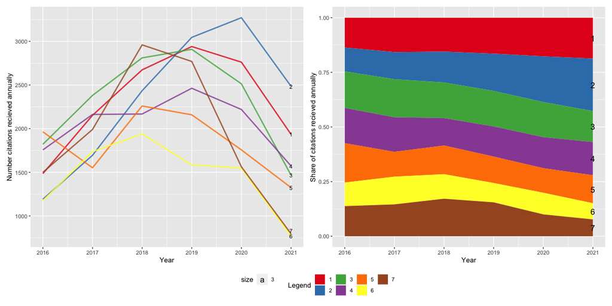

## 4.2 Technical description

In a co-cittion network, the strength of the relationship between a reference pair $m$ and $n$ ($s_{m,n}^{coc}$) is expressed by the number of publications $C$ which are jointly citing reference $m$ and $n$.

$$s_{m,n}^{coc} = \sum_i c_{i,m}
c_{i,n}$$

The intuition here is that references which are frequently cited together are likely to share commonalities in theory, topic, methodology, or context. It can be interpreted as a measure of similarity as evaluated by other researchers that decide to jointly cite both references. Because the publication process is time-consuming, co-citation is a backward-looking measure, which is appropriate to map the relationship between core literature of a field.

# 5 Research Areas: Bibliographic coupling analysis

## 5.1 Research Areas main summary

This is arguably the more interesting part. Here, we identify the literature’s current knowledge frontier by carrying out a bibliographic coupling analysis of the publications in our corpus. This measure uses bibliographical information of publications to establish a similarity relationship between them. Again, method details to be found in the tab `Technical description`. As you will see, we identify the main research area, but also a set of adjacent research areas with some theoretical/methodological/application overlap.

### 5.1.1 Main Characteristics

To identify communities in the field’s knowledge frontier (labeled **research areas**) we again use the **Lovain Algorithm** (Blondel et al., 2008). We identify the following communities = research areas.

| com | com_name | n | density_int |
| --- | --- | --- | --- |
| 1 | 1 | 1199 | 0.119 |
| 2 | 2 | 918 | 0.106 |
| 3 | 3 | 898 | 1.019 |
| 4 | 4 | 747 | 0.315 |
| 5 | 5 | 745 | 0.323 |
| 6 | 6 | 734 | 0.481 |
| 7 | 7 | 599 | 0.168 |
| 8 | 8 | 478 | 0.859 |
| 9 | 9 | 106 | 0.926 |

| com | com_name | topic_name |
| --- | --- | --- |
| 1 | 1 | 5 |
| 1 | 1 | 6 |
| 1 | 1 | 10 |
| 2 | 2 | 9 |
| 2 | 2 | 7 |
| 2 | 2 | 12 |
| 3 | 3 | 3 |
| 3 | 3 | 8 |
| 3 | 3 | 4 |
| 4 | 4 | 5 |
| 4 | 4 | 3 |
| 4 | 4 | 8 |
| 5 | 5 | 6 |
| 5 | 5 | 10 |
| 5 | 5 | 1 |
| 6 | 6 | 6 |
| 6 | 6 | 1 |
| 6 | 6 | 5 |
| 7 | 7 | 2 |
| 7 | 7 | 7 |
| 7 | 7 | 1 |
| 8 | 8 | 4 |
| 8 | 8 | 1 |
| 8 | 8 | 3 |
| 9 | 9 | 6 |
| 9 | 9 | 1 |
| 9 | 9 | 5 |
| NA | NA | 2 |
| NA | NA | 9 |
| NA | NA | 12 |

### 5.1.2 Categorization

I up to now gain only provide the 10 most central articles, which can be used to classify them

| com_name | AU | PY | TI | dgr_int | TC | TC_year |
| --- | --- | --- | --- | --- | --- | --- |
| 1 | CECCARELLI M;BARTHEL F... | 2016 | MOLECULAR PROFILING REVEALS BIOLOGICALLY DISCRETE SUBSETS AND PATHWAYS OF PROGRESSION IN DIFFUSE GLIOMA | 5.8280489 | 1083 | 180.500000 |
| 1 | WANG Q;HU B;HU X;KIM H... | 2017 | TUMOR EVOLUTION OF GLIOMA-INTRINSIC GENE EXPRESSION SUBTYPES ASSOCIATES WITH IMMUNOLOGICAL CHANGES IN THE MICROENVIRONMENT | 6.2570923 | 632 | 126.400000 |
| 1 | LIU J;LICHTENBERG T;HO... | 2018 | AN INTEGRATED TCGA PAN-CANCER CLINICAL DATA RESOURCE TO DRIVE HIGH-QUALITY SURVIVAL OUTCOME ANALYTICS | 3.0336201 | 974 | 243.500000 |
| 1 | COLAPRICO A;SILVA TC;O... | 2016 | TCGABIOLINKS: AN R/BIOCONDUCTOR PACKAGE FOR INTEGRATIVE ANALYSIS OF TCGA DATA | 2.4672309 | 1070 | 178.333333 |
| 1 | NEFTEL C;LAFFY J;FILBI... | 2019 | AN INTEGRATIVE MODEL OF CELLULAR STATES, PLASTICITY, AND GENETICS FOR GLIOBLASTOMA | 4.8991952 | 502 | 167.333333 |
| 1 | CHANDRASHEKAR DS;BASHE... | 2017 | UALCAN: A PORTAL FOR FACILITATING TUMOR SUBGROUP GENE EXPRESSION AND SURVIVAL ANALYSES | 0.7837219 | 2159 | 431.800000 |
| 1 | SU R;DONG L;LI C;NACHT... | 2018 | R-2HG EXHIBITS ANTI-TUMOR ACTIVITY BY TARGETING FTO/M6A/MYC/CEBPA SIGNALING | 2.6743798 | 479 | 119.750000 |
| 1 | CAVALLI FMG;REMKE M;RA... | 2017 | INTERTUMORAL HETEROGENEITY WITHIN MEDULLOBLASTOMA SUBGROUPS | 2.0524417 | 508 | 101.600000 |
| 1 | LIAO Y;SMYTH GK;SHI W | 2019 | THE R PACKAGE RSUBREAD IS EASIER, FASTER, CHEAPER AND BETTER FOR ALIGNMENT AND QUANTIFICATION OF RNA SEQUENCING READS | 1.8199566 | 539 | 179.666667 |
| 1 | JACOB F;SALINAS RD;ZHA... | 2020 | A PATIENT-DERIVED GLIOBLASTOMA ORGANOID MODEL AND BIOBANK RECAPITULATES INTER- AND INTRA-TUMORAL HETEROGENEITY | 4.4926787 | 217 | 108.500000 |
| 2 | MAUTHE M;ORHON I;ROCCH... | 2018 | CHLOROQUINE INHIBITS AUTOPHAGIC FLUX BY DECREASING AUTOPHAGOSOME-LYSOSOME FUSION | 0.8711046 | 744 | 186.000000 |
| 2 | SINGH SS;VATS S;CHIA A... | 2018 | DUAL ROLE OF AUTOPHAGY IN HALLMARKS OF CANCER | 2.1865347 | 271 | 67.750000 |
| 2 | SHARIFI MN;MOWERS EE;D... | 2016 | AUTOPHAGY PROMOTES FOCAL ADHESION DISASSEMBLY AND CELL MOTILITY OF METASTATIC TUMOR CELLS THROUGH THE DIRECT INTERACTION O... | 3.0563539 | 177 | 29.500000 |
| 2 | GUO JY;TENG X;LADDHA S... | 2016 | AUTOPHAGY PROVIDES METABOLIC SUBSTRATES TO MAINTAIN ENERGY CHARGE AND NUCLEOTIDE POOLS IN RAS-DRIVEN LUNG CANCER CELLS | 2.5786047 | 206 | 34.333333 |
| 2 | PIETROCOLA F;POL J;VAC... | 2016 | CALORIC RESTRICTION MIMETICS ENHANCE ANTICANCER IMMUNOSURVEILLANCE | 1.6069340 | 278 | 46.333333 |
| 2 | WHITE E | 2016 | AUTOPHAGY AND P53 | 2.6478072 | 168 | 28.000000 |
| 2 | YANG A;HERTER-SPRIE G;... | 2018 | AUTOPHAGY SUSTAINS PANCREATIC CANCER GROWTH THROUGH BOTH CELL-AUTONOMOUS AND NONAUTONOMOUS MECHANISMS | 2.2279286 | 165 | 41.250000 |
| 2 | JANJI B;BERCHEM G;CHOU... | 2018 | TARGETING AUTOPHAGY IN THE TUMOR MICROENVIRONMENT: NEW CHALLENGES AND OPPORTUNITIES FOR REGULATING TUMOR IMMUNITY | 6.8463433 | 45 | 11.250000 |
| 2 | HUANG T;KIM CK;ALVAREZ... | 2017 | MST4 PHOSPHORYLATION OF ATG4B REGULATES AUTOPHAGIC ACTIVITY, TUMORIGENICITY, AND RADIORESISTANCE IN GLIOBLASTOMA | 2.6008058 | 117 | 23.400000 |
| 2 | KINSEY CG;CAMOLOTTO SA... | 2019 | PROTECTIVE AUTOPHAGY ELICITED BY RAF→MEK→ERK INHIBITION SUGGESTS A TREATMENT STRATEGY FOR RAS-DRIVEN CANCERS | 1.0605398 | 269 | 89.666667 |
| 3 | GEIGER R;RIECKMANN JC;... | 2016 | L-ARGININE MODULATES T CELL METABOLISM AND ENHANCES SURVIVAL AND ANTI-TUMOR ACTIVITY | 10.6605202 | 617 | 102.833333 |
| 3 | GEYER PE;KULAK NA;PICH... | 2016 | PLASMA PROTEOME PROFILING TO ASSESS HUMAN HEALTH AND DISEASE | 16.7178052 | 330 | 55.000000 |
| 3 | MEIER F;BRUNNER A-D;KO... | 2018 | ONLINE PARALLEL ACCUMULATION–SERIAL FRAGMENTATION (PASEF) WITH A NOVEL TRAPPED ION MOBILITY MASS SPECTROMETER | 14.6773418 | 243 | 60.750000 |
| 3 | WHITHAM M;PARKER BL;FR... | 2018 | EXTRACELLULAR VESICLES PROVIDE A MEANS FOR TISSUE CROSSTALK DURING EXERCISE | 13.5161195 | 247 | 61.750000 |
| 3 | STEGER M;DIEZ F;DHEKNE... | 2017 | SYSTEMATIC PROTEOMIC ANALYSIS OF LRRK2-MEDIATED RAB GTPASE PHOSPHORYLATION ESTABLISHES A CONNECTION TO CILIOGENESIS | 17.2448724 | 181 | 36.200000 |
| 3 | ITZHAK DN;TYANOVA S;CO... | 2016 | GLOBAL, QUANTITATIVE AND DYNAMIC MAPPING OF PROTEIN SUBCELLULAR LOCALIZATION | 10.1717003 | 268 | 44.666667 |
| 3 | SCHROEDER BO;BIRCHENOU... | 2018 | BIFIDOBACTERIA OR FIBER PROTECTS AGAINST DIET-INDUCED MICROBIOTA-MEDIATED COLONIC MUCUS DETERIORATION | 8.8777270 | 285 | 71.250000 |
| 3 | GRASSL N;KULAK NA;PICH... | 2016 | ULTRA-DEEP AND QUANTITATIVE SALIVA PROTEOME REVEALS DYNAMICS OF THE ORAL MICROBIOME | 20.6468269 | 121 | 20.166667 |
| 3 | BONFIGLIO JJ;FONTANA P... | 2017 | SERINE ADP-RIBOSYLATION DEPENDS ON HPF1 | 14.7547585 | 157 | 31.400000 |
| 3 | BACHE N;GEYER PE;BEKKE... | 2018 | A NOVEL LC SYSTEM EMBEDS ANALYTES IN PRE-FORMED GRADIENTS FOR RAPID, ULTRA-ROBUST PROTEOMICS | 21.2038243 | 107 | 26.750000 |

[output cut: 70 more lines]

### 5.1.3 Development

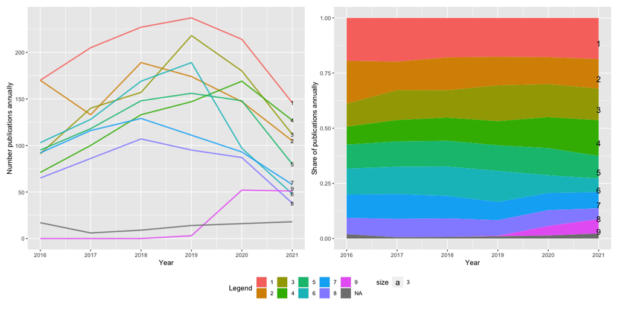

### 5.1.4 Connectivity between the research areas

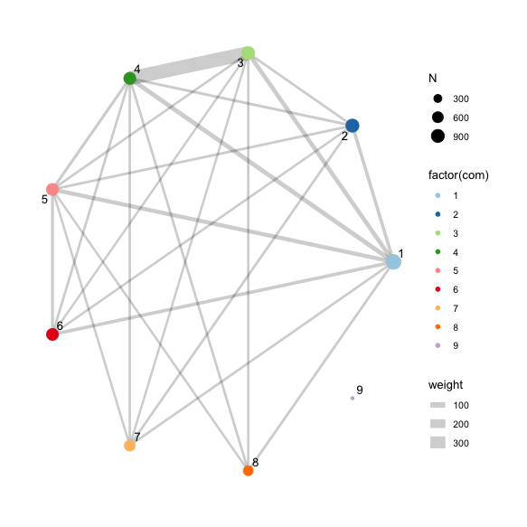

## 5.2 Technical description

In a bibliographic coupling network, the **coupling-strength** between publications is determined by the number of commonly cited references they share, assuming a common pool of references to indicate similarity in context, methods, or theory. Formally, the strength of the relationship between a publication pair $i$ and $j$ ($s_{i,j}^{bib}$) is expressed by the number of commonly cited references.

$$s_{i,j}^{bib} = \sum_m c_{i,m}
c_{j,m}$$

Since our corpus contains publications which differ strongly in terms of the number of cited references, we normalize the coupling strength by the Jaccard similarity coefficient. Here, we weight the intercept of two publications’ bibliography (shared refeences) by their union (number of all references cited by either $i$ or $j$). It is bounded between zero and one, where one indicates the two publications to have an identical bibliography, and zero that they do not share any cited reference. Thereby, we prevent publications from having high coupling strength due to a large bibliography (e.g., literature surveys).

$$S_{i,j}^{jac-bib} =\frac{C(i \cap
j)}{C(i \cup j)} = \frac{s_{i,j}^{bib}}{c_i + c_j -
s_{i,j}^{bib}}$$

More recent articles have a higher pool of possible references to co-cite to, hence they are more likely to be coupled. Consequently, bibliographic coupling represents a forward looking measure, and the method of choice to identify the current knowledge frontier at the point of analysis.

# 6 Additional analysis

## 6.1 Authors, Themes & Journals